# 5-5. Correlation matrix : An R function to do all you need

Correlation matrix analysis is very useful to study dependences or associations between variables.  
This article provides a custom R function, `rquery.cormat()`, for calculating and visualizing easily acorrelation matrix.

The result is a list containing, the correlation coefficient tables and the p-values of the correlations.  
In the result, the variables are reordered according to the level of the correlation which can help to quickly identify the most associated variables.

A graph is also generated to visualize the correlation matrix using a correlogram or a heatmap.

### 1. Prerequisites

- The `rquery.cormat()` function requires the installation of `{corrplot}` package.
- Before proceeding, install it using he following R code :

```r
# install.packages("corrplot")
```

- To use the `rquery.cormat()` function, you can source it as follow :

```r
source("scripts/rquery_cormat.r")
```

- A simplified format of the function is :
  - Description of the arguments:
    - `x` : matrix of data values
    - `type` : Possible values are `lower` (default), `upper`, `full` or `flatten`. It displays the lower or upper triangular of the matrix, full or flatten matrix.
    - `graph` : if TRUE, a `correlogram` or `heatmap` is generated to visualize the correlation matrix.
    - `graphType` : Type of graphs. Possible values are `correlogram` or `heatmap`.
    - `col` : colors to use for the `correlogram` or the `heatmap`.
    - `…` : Further arguments to be passed to `cor{stats}` or `cor.test{stats}` function.

```r
rquery.cormat(
          x,
          type=c('lower', 'upper', 'full', 'flatten'),
          graph=TRUE,
          graphType=c("correlogram", "heatmap"),
          col=NULL,
          ...
        )
```

### 2. Example of data

- The `mtcars{datasets}` data is used in the following examples :

```r
mydata <- mtcars[ , c(1,3,4,5,6,7)]

library(dplyr, quietly = TRUE)
sample_n(tbl = mydata, size = 10, replace = FALSE)
```

```
##                    mpg  disp  hp drat    wt  qsec
## Maserati Bora     15.0 301.0 335 3.54 3.570 14.60
## Hornet 4 Drive    21.4 258.0 110 3.08 3.215 19.44
## Pontiac Firebird  19.2 400.0 175 3.08 3.845 17.05
## Datsun 710        22.8 108.0  93 3.85 2.320 18.61
## Merc 230          22.8 140.8  95 3.92 3.150 22.90
## Hornet Sportabout 18.7 360.0 175 3.15 3.440 17.02
## Toyota Corona     21.5 120.1  97 3.70 2.465 20.01
## Merc 450SE        16.4 275.8 180 3.07 4.070 17.40
## AMC Javelin       15.2 304.0 150 3.15 3.435 17.30
## Fiat X1-9         27.3  79.0  66 4.08 1.935 18.90
```

### 3. Computing the correlation matrix

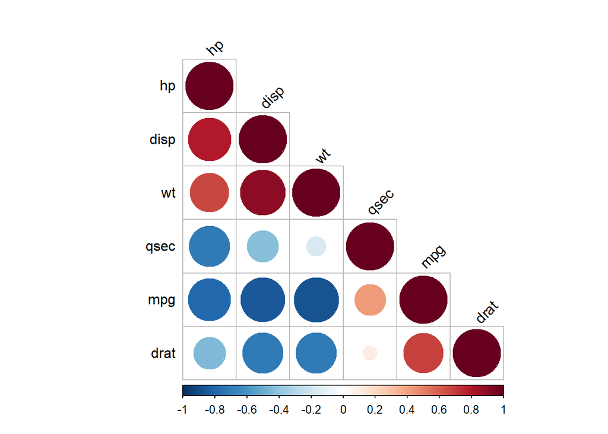

```
## $r
##         hp  disp    wt  qsec  mpg drat
## hp       1
## disp  0.79     1
## wt    0.66  0.89     1
## qsec -0.71 -0.43 -0.17     1
## mpg  -0.78 -0.85 -0.87  0.42    1
## drat -0.45 -0.71 -0.71 0.091 0.68    1
##
## $p
##           hp    disp      wt  qsec     mpg drat
## hp         0
## disp 7.1e-08       0
## wt   4.1e-05 1.2e-11       0
## qsec 5.8e-06   0.013    0.34     0
## mpg  1.8e-07 9.4e-10 1.3e-10 0.017       0
## drat    0.01 5.3e-06 4.8e-06  0.62 1.8e-05    0
##
## $sym
##      hp disp wt qsec mpg drat
## hp   1
## disp ,  1
## wt   ,  +    1
## qsec ,  .       1
## mpg  ,  +    +  .    1
## drat .  ,    ,       ,   1
## attr(,"legend")
## [1] 0 ' ' 0.3 '.' 0.6 ',' 0.8 '+' 0.9 '*' 0.95 'B' 1
```

```r
rquery.cormat(mydata)
```

- The result of `rquery.cormat` function is a list containing the following components :
  - `r` : The table of correlation coefficients
  - `p` : Table of p-values corresponding to the significance levels of the correlations
  - `sym` : A representation of the correlation matrix in which coefficients are replaced by symbols according to the strength of the dependence.
- In the generated graph, negative correlations are in blue and positive ones in red color.

### 4. Upper triangle of the correlation matrix

> Note that in the result above, only the lower triangle of the correlation matrix is shown by default.
- You can use the following R script to get the upper triangle or the full correlation matrix.

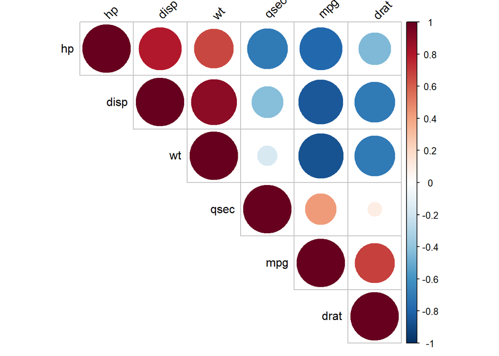

```
## $r
##      hp disp   wt  qsec   mpg  drat
## hp    1 0.79 0.66 -0.71 -0.78 -0.45
## disp       1 0.89 -0.43 -0.85 -0.71
## wt              1 -0.17 -0.87 -0.71
## qsec                  1  0.42 0.091
## mpg                         1  0.68
## drat                              1
##
## $p
##      hp    disp      wt    qsec     mpg    drat
## hp    0 7.1e-08 4.1e-05 5.8e-06 1.8e-07    0.01
## disp          0 1.2e-11   0.013 9.4e-10 5.3e-06
## wt                    0    0.34 1.3e-10 4.8e-06
## qsec                          0   0.017    0.62
## mpg                                   0 1.8e-05
## drat                                          0
##
## $sym
##      hp disp wt qsec mpg drat
## hp   1  ,    ,  ,    ,   .
## disp    1    +  .    +   ,
## wt           1       +   ,
## qsec            1    .
## mpg                  1   ,
## drat                     1
## attr(,"legend")
## [1] 0 ' ' 0.3 '.' 0.6 ',' 0.8 '+' 0.9 '*' 0.95 'B' 1
```

```r
rquery.cormat(mydata, type="upper")
```

### 5. Full correlation matrix

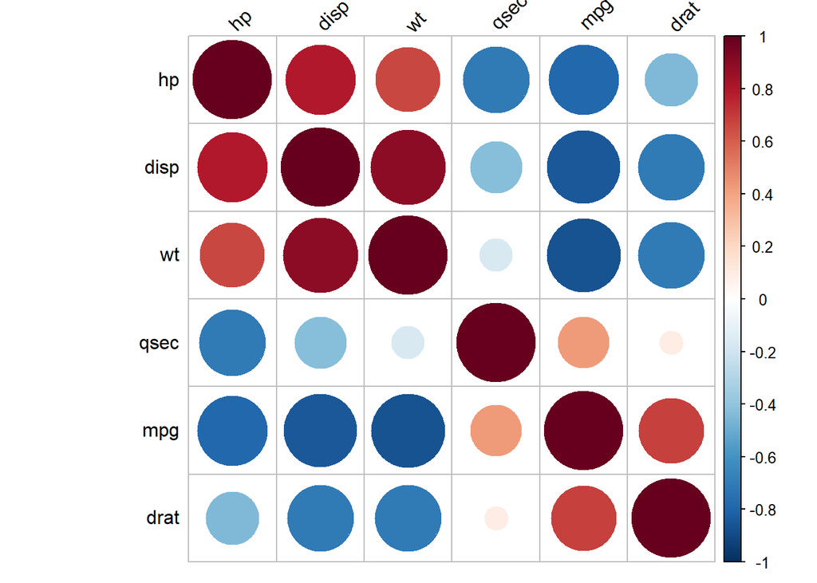

```
## $r
##         hp  disp    wt   qsec   mpg   drat
## hp    1.00  0.79  0.66 -0.710 -0.78 -0.450
## disp  0.79  1.00  0.89 -0.430 -0.85 -0.710
## wt    0.66  0.89  1.00 -0.170 -0.87 -0.710
## qsec -0.71 -0.43 -0.17  1.000  0.42  0.091
## mpg  -0.78 -0.85 -0.87  0.420  1.00  0.680
## drat -0.45 -0.71 -0.71  0.091  0.68  1.000
##
## $p
##           hp    disp      wt    qsec     mpg    drat
## hp   0.0e+00 7.1e-08 4.1e-05 5.8e-06 1.8e-07 1.0e-02
## disp 7.1e-08 0.0e+00 1.2e-11 1.3e-02 9.4e-10 5.3e-06
## wt   4.1e-05 1.2e-11 0.0e+00 3.4e-01 1.3e-10 4.8e-06
## qsec 5.8e-06 1.3e-02 3.4e-01 0.0e+00 1.7e-02 6.2e-01
## mpg  1.8e-07 9.4e-10 1.3e-10 1.7e-02 0.0e+00 1.8e-05
## drat 1.0e-02 5.3e-06 4.8e-06 6.2e-01 1.8e-05 0.0e+00
##
## $sym
##      hp disp wt qsec mpg drat
## hp   1
## disp ,  1
## wt   ,  +    1
## qsec ,  .       1
## mpg  ,  +    +  .    1
## drat .  ,    ,       ,   1
## attr(,"legend")
## [1] 0 ' ' 0.3 '.' 0.6 ',' 0.8 '+' 0.9 '*' 0.95 'B' 1
```

```r
rquery.cormat(mydata, type="full")
```

### 6. Change the colors of the correlogram

```r
col <- colorRampPalette(c("blue", "white", "red"))(20)
cormat <- rquery.cormat(mydata, type="full", col=col)
```

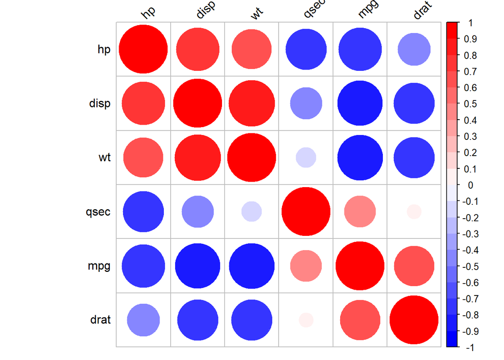

### 7. Draw a heatmap

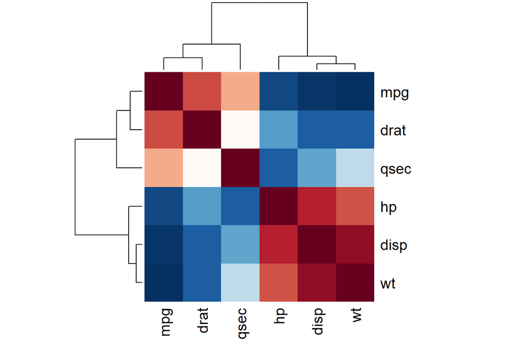

```r
cormat <- rquery.cormat(mydata, graphType="heatmap")
```

- To calculate the correlation matrix without plotting the graph, you can use the following R script :

```r
rquery.cormat(mydata, graph=FALSE)
```

```
## $r
##         hp  disp    wt  qsec  mpg drat
## hp       1
## disp  0.79     1
## wt    0.66  0.89     1
## qsec -0.71 -0.43 -0.17     1
## mpg  -0.78 -0.85 -0.87  0.42    1
## drat -0.45 -0.71 -0.71 0.091 0.68    1
##
## $p
##           hp    disp      wt  qsec     mpg drat
## hp         0
## disp 7.1e-08       0
## wt   4.1e-05 1.2e-11       0
## qsec 5.8e-06   0.013    0.34     0
## mpg  1.8e-07 9.4e-10 1.3e-10 0.017       0
## drat    0.01 5.3e-06 4.8e-06  0.62 1.8e-05    0
##
## $sym
##      hp disp wt qsec mpg drat
## hp   1
## disp ,  1
## wt   ,  +    1
## qsec ,  .       1
## mpg  ,  +    +  .    1
## drat .  ,    ,       ,   1
## attr(,"legend")
## [1] 0 ' ' 0.3 '.' 0.6 ',' 0.8 '+' 0.9 '*' 0.95 'B' 1
```

### 8. Format the correlation table

- The R code below can be used to format the correlation matrix into a table of four columns containing :
  - The names of rows/columns
  - The correlation coefficients
  - The p-values
- For this end, use the argument : type=“flatten”

```r
rquery.cormat(mydata, type="flatten", graph=FALSE)
```

```
## $r
##     row column    cor       p
## 1    hp   disp  0.790 7.1e-08
## 2    hp     wt  0.660 4.1e-05
## 3  disp     wt  0.890 1.2e-11
## 4    hp   qsec -0.710 5.8e-06
## 5  disp   qsec -0.430 1.3e-02
## 6    wt   qsec -0.170 3.4e-01
## 7    hp    mpg -0.780 1.8e-07
## 8  disp    mpg -0.850 9.4e-10
## 9    wt    mpg -0.870 1.3e-10
## 10 qsec    mpg  0.420 1.7e-02
## 11   hp   drat -0.450 1.0e-02
## 12 disp   drat -0.710 5.3e-06
## 13   wt   drat -0.710 4.8e-06
## 14 qsec   drat  0.091 6.2e-01
## 15  mpg   drat  0.680 1.8e-05
##
## $p
## NULL
##
## $sym
## NULL
```

### 9. Description of `rquery.cormat` function